# Data Mining Final Project

```r
# upper_limit = 43.35
# We are selecting upper limit as 1.5 times interquantile range above the 75th percentile here
outliers_upperlimit <- quantile(raw.data$dti, 0.75) + 1.5 * IQR(raw.data$dti)


index.outliers.dti <- which(raw.data$dti > outliers_upperlimit | raw.data$dti < 0 )

# 4944 outliers
length(index.outliers.dti)
```

```
## [1] 4944
```

```r
# Removing outliers
raw.data <- raw.data[-index.outliers.dti,]
```

```r
# Removing outliers for open_acc
summary(raw.data$open_acc)
```

```
##    Min. 1st Qu.  Median    Mean 3rd Qu.    Max.
##    0.00    8.00   11.00   11.59   14.00   90.00
```

```r
# For open values, if open accounts<0 or >50, we've considered them to be outliers
index.outliers2 = which(raw.data$open_acc > 50 | raw.data$open_acc <0 )

# 198 outliers
length(index.outliers2)
```

```
## [1] 198
```

```r
# Removing outliers
raw.data = raw.data[-index.outliers2,]
```

```r
#Removing outliers for pub_rec
summary(raw.data$pub_rec)
```

```
##    Min. 1st Qu.  Median    Mean 3rd Qu.    Max.
##  0.0000  0.0000  0.0000  0.2155  0.0000 86.0000
```

```r
# For pub_rec < 0 or > 20, we've considered them to be outliers
index.outliers3 <- which(raw.data$pub_rec > 20 | raw.data$pub_rec <0 )

# 26 outliers
length(index.outliers3)
```

```
## [1] 26
```

```r
# Removing outliers
raw.data <- raw.data[-index.outliers3,]
```

```r
#Removing outliers for delinq_2yrs
summary(raw.data$delinq_2yrs)
```

```
##    Min. 1st Qu.  Median    Mean 3rd Qu.    Max.
##  0.0000  0.0000  0.0000  0.3177  0.0000 39.0000
```

```r
index.outliers4 <- which(raw.data$delinq_2yrs > 20 | raw.data$delinq_2yrs <0 ) #7 outliers

# 18 outliers
length(index.outliers4)
```

```
## [1] 18
```

```r
raw.data = raw.data[-index.outliers4,] #Removing observations
```

```r
summary(raw.data$installment)
```

```
##    Min. 1st Qu.  Median    Mean 3rd Qu.    Max.
##    4.93  248.66  375.43  437.60  579.16 1719.83
```

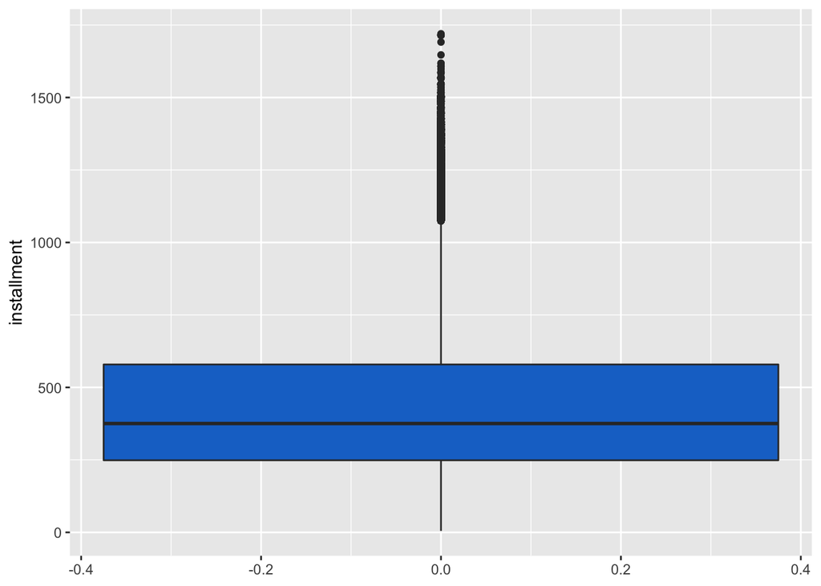

```r
ggplot(data = raw.data, mapping = aes(y = installment)) + geom_boxplot(fill = "dodgerblue3")
```

```r
# Outlier value - 1105.875
outliers_upperlimit <- quantile(raw.data$installment, 0.75) + 1.5 * IQR(raw.data$installment)

index.outliers.installment <- which(raw.data$installment > outliers_upperlimit | raw.data$installment < 0 )

# 40651 outliers
length(index.outliers.installment)
```

```
## [1] 40651
```

```r
# Removing outliers
raw.data <- raw.data[-index.outliers.installment,]
```

```r
#Removing outliers for revol_bal
summary(raw.data$revol_bal)
```

```
##    Min. 1st Qu.  Median    Mean 3rd Qu.    Max.
##       0    5853   10886   15554   19076 2568995
```

```r
#plot(raw.data$revol_bal)

index.outliers5 <- which(raw.data$revol_bal > 500000 | raw.data$revol_bal <0 ) #56 outliers

# 124 outliers
length(index.outliers5)
```

```
## [1] 124
```

```r
raw.data <- raw.data[-index.outliers5,] #Removing observations
```

```r
lending.club.relevant.data = raw.data # reverting the dataframe
```

```r
#maping the categories to default and not default
lending.club.relevant.data$loan_status = mapvalues(lending.club.relevant.data$loan_status, from = c("Does not meet the credit policy. Status:Fully Paid", "Fully Paid", "Charged Off", "Late (31-120 days)", "In Grace Period", "Does not meet the credit policy. Status:Charged Off", "Late (16-30 days)", "Current" ), to = c("Not Default", "Not Default", "Default", "Default", "Default", "Default","Default", "Default" ))
```

```r
# as the `emp_length` is a categorical variable, we will make four bins 'Unemployed', '0-2', '3-5', '6-9', and '10+' for intuitive sense.

lending.club.relevant.data$emp_length = mapvalues(lending.club.relevant.data$emp_length, from = c("< 1 year", "1 year", "2 years",   "3 years", "4 years", "5 years", "6 years","7 years","8 years","9 years", "n/a" ), to = c("0-2", "0-2", "0-2", "3-5", "3-5", "3-5", "6-9", "6-9", "6-9", "6-9", "Unemployed"))

lending.club.relevant.data$emp_length = factor(lending.club.relevant.data$emp_length, levels = c("Unemployed", "0-2", "3-5", "6-9", "10+ years"))
```

We converted `n/a` to `Unemployed` because n/a only applies for borrowers if they do not have any employment history. Thus, we have labelled those borrowers as `Unemployed`.

## Exploratory Data Analysis

We will leverage various visualization techniques in this section to understand the summary of the features we selected and their relation with the loan status, if any.

### 1. Loan Status

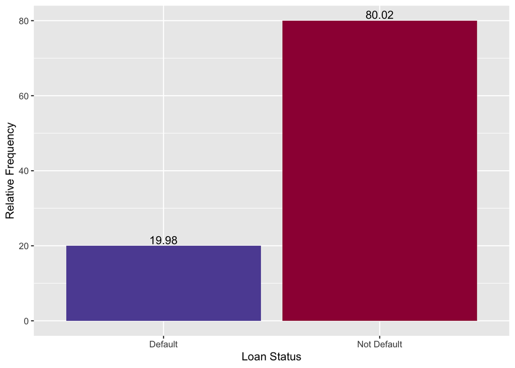

```r
lending.club.relevant.data %>%
  group_by(loan_status) %>%
  summarize(frequency = n()) %>%
ggplot(mapping = aes(x = reorder(loan_status, frequency), y = frequency * 100 / sum(frequency), fill = frequency * 100 / sum(frequency)))+
geom_bar(stat = "identity") +
labs(x = "Loan Status",  y = "Relative Frequency") +
theme(plot.title = element_text(hjust = 0.5)) + geom_text(aes(label = round((frequency * 100 / sum(frequency)), 2)), position= "stack",   vjust=-0.25) + scale_fill_gradientn(name = '',colours = rev(brewer.pal(10,'Spectral'))) + theme(legend.position = "none")
```

The bar graph shows an unequal distribution of the loan status in the dataset. 80.02% of borrowers fully repaid their loans while 19.98% (~1/5) defaulted on their loans. The classes, as a result, are imbalanced but expected. In any lending practice, we would expect a higher proportion of non-default borrowers.

### 2. Loan Term

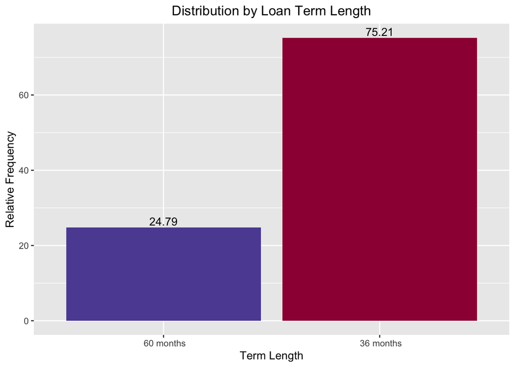

```r
lending.club.relevant.data %>%
  group_by(term) %>%
  summarize(frequency = n()) %>%
ggplot(mapping = aes(x = reorder(term, frequency), y = frequency * 100 / sum(frequency), fill = frequency * 100 / sum(frequency))) + geom_bar(stat = "identity") + labs(x = "Term Length",  y = "Relative Frequency", title = "Distribution by Loan Term Length") + theme(plot.title = element_text(hjust = 0.5)) + scale_fill_gradientn(name = '',colours = rev(brewer.pal(10,'Spectral'))) + theme(legend.position = "none") + geom_text(aes(label = round((frequency * 100 / sum(frequency)), 2)), position= "stack",   vjust=-0.25)
```

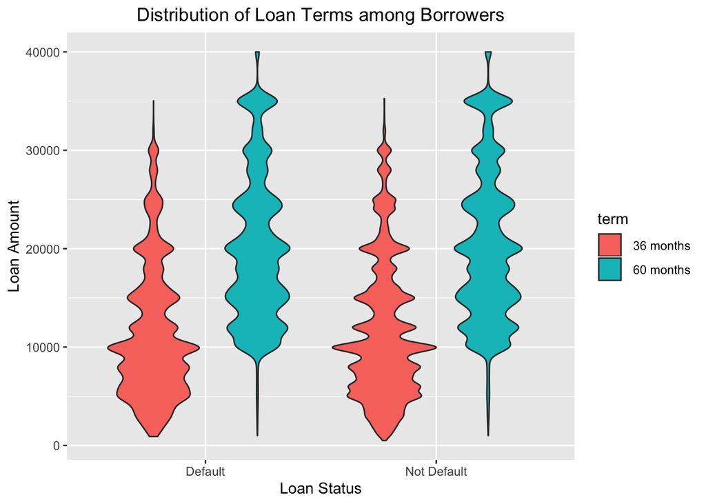

```r
ggplot(data = lending.club.relevant.data, aes(x = loan_status, y = loan_amnt, fill  = term)) + geom_violin() + labs(x = "Loan Status", y = "Loan Amount", title = "Distribution of Loan Terms among Borrowers") + theme(plot.title = element_text(hjust = 0.5))
```

As the bar graph depicts, 3 out of 4 borrowers borrow for short-term (36 months). The pattern is true across both defaulters and non-defaulters. Moreoever, the violin plot shows us that short-term loan also has lower loan amount. Finally, there is not systematic relationship with defaulters and (loan amount and loan-term).

### 3. Borrowers Home Ownership Type

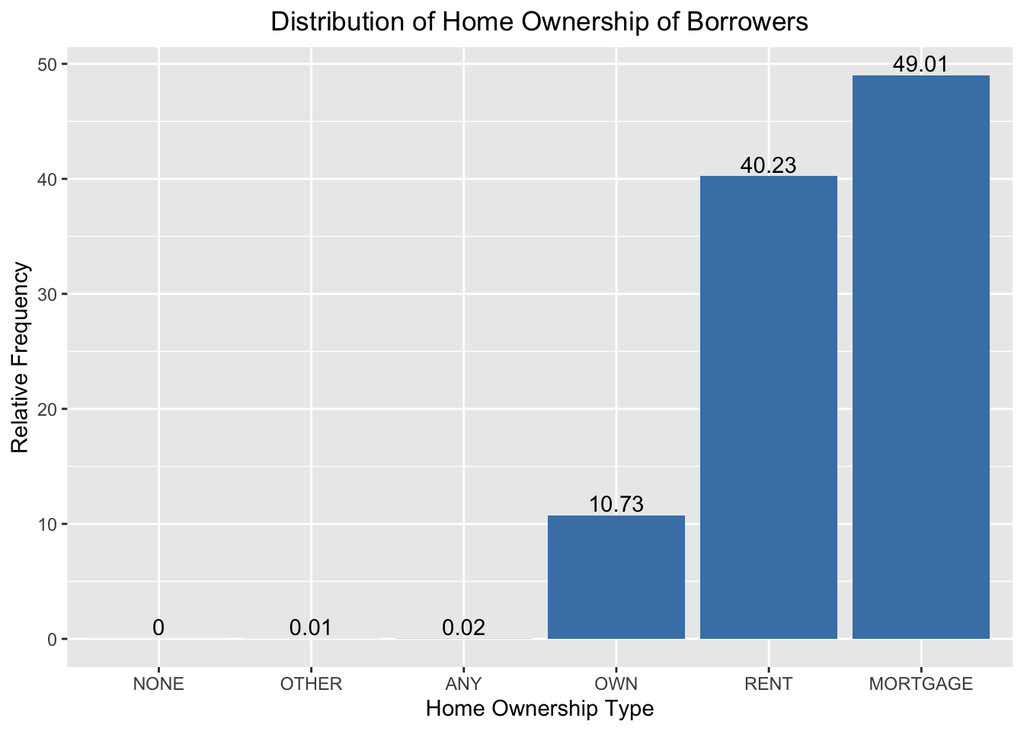

```r
# bar graph of home ownership of borrowers

lending.club.relevant.data %>%
  group_by(home_ownership) %>%
  summarize(frequency = n()) %>%
ggplot(mapping = aes(x = reorder(home_ownership, frequency), y = frequency * 100 / sum(frequency))) +
geom_bar(stat = "identity", fill  = "steelblue") + labs(x = "Home Ownership Type",  y = "Relative Frequency", title = "Distribution of Home Ownership of Borrowers") +
theme(plot.title = element_text(hjust = 0.5)) + geom_text(aes(label = round((frequency * 100 / sum(frequency)), 2)), position= "stack", vjust=-0.25)
```

As we would expect, an overwhelming majority of the borrowers, as the figure above shows, either have mortgages or rent their real estate.

### 4. Borrowers’ Grade

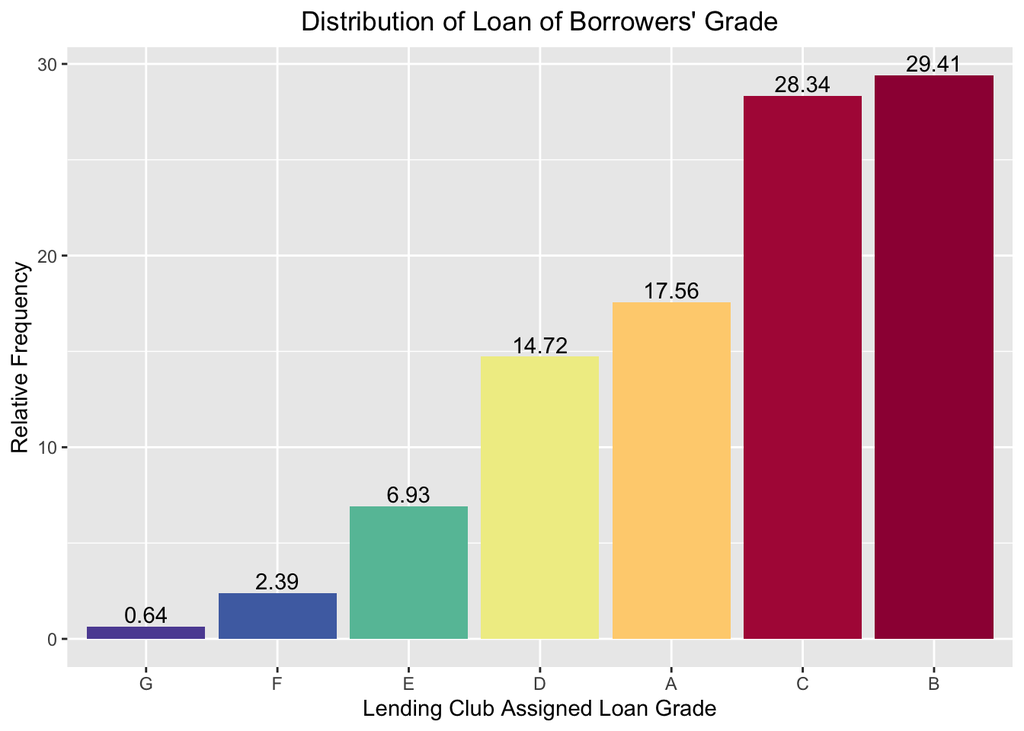

```r
# to visualize the significant types of loan grade that will be used in model

lending.club.relevant.data %>%
  group_by(grade) %>%
  summarize(frequency = n()) %>%
ggplot(mapping = aes(x = reorder(grade, frequency), y = frequency * 100 / sum(frequency), fill = frequency * 100 / sum(frequency)))+
geom_bar(stat = "identity") +
labs(x = "Lending Club Assigned Loan Grade",  y = "Relative Frequency", title = "Distribution of Loan of Borrowers' Grade") +
theme(plot.title = element_text(hjust = 0.5)) + geom_text(aes(label = round((frequency * 100 / sum(frequency)), 2)), position= "stack",   vjust=-0.25) + scale_fill_gradientn(name = '',colours = rev(brewer.pal(10,'Spectral'))) + theme(legend.position = "none")
```

Lending Club assigns a grade to each loan to reflect the credit risk of the corresponding loan. Lower the loan grade, higher the associated risk. The graph above depicts that a majority of the loans (~60%) fall in either B or C category. Not surprisingly, the relative frequencies of lower grades loan (e.g. F and G) are low. Overall, we can infer that the loans at Lending Club have a little to moderate level of risk.

### 5. Distribution of Loan Grade

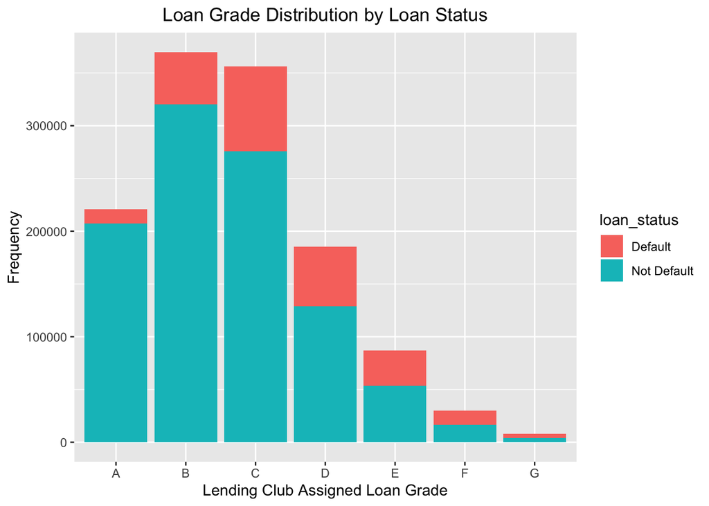

```r
ggplot(data = lending.club.relevant.data, mapping = aes(x = grade, fill  = loan_status)) +
geom_bar() + labs(x = "Lending Club Assigned Loan Grade", y = "Frequency", title = "Loan Grade Distribution by Loan Status") + theme(plot.title = element_text(hjust = 0.5))
```

This is interesting! A higher calibre loan grade, say grade A, has as a substantially low number of defaulters. However, the percentage of defaulters increases as the loan grade decreases. For example, the Loan Grade C has around 25% of defaulters; as we move to loan grade D, the percentage increases to appox. 33%. And the trend continues. The LC assigned loan grade, therefore, could be a loose proxy to an individual defaulting on the loan.

### 6. Year of Employment among Borrowers

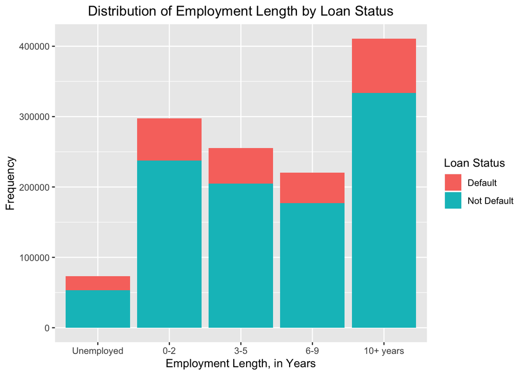

```r
ggplot(data = lending.club.relevant.data, mapping = aes(x = emp_length, fill  = loan_status)) + geom_bar() +labs(x = "Employment Length, in Years", y =  "Frequency", title = "Distribution of Employment Length by Loan Status", fill = "Loan Status") + theme(plot.title = element_text(hjust = 0.5))
```

The bar graph demonstrates that a majority of borrowers have an employment history of 10 years and above. As the dataset has higher volume of non-default borrowers, we expectedly observe a higher frequency of non-defaulters in each employment length. However, there does not exist a systematic difference between default and non-default borrowers in employment length.

Interestingly, unemployed borrowers tend to be more non-defaulters than defaulters.

### 7. Borrower’s Annual Income

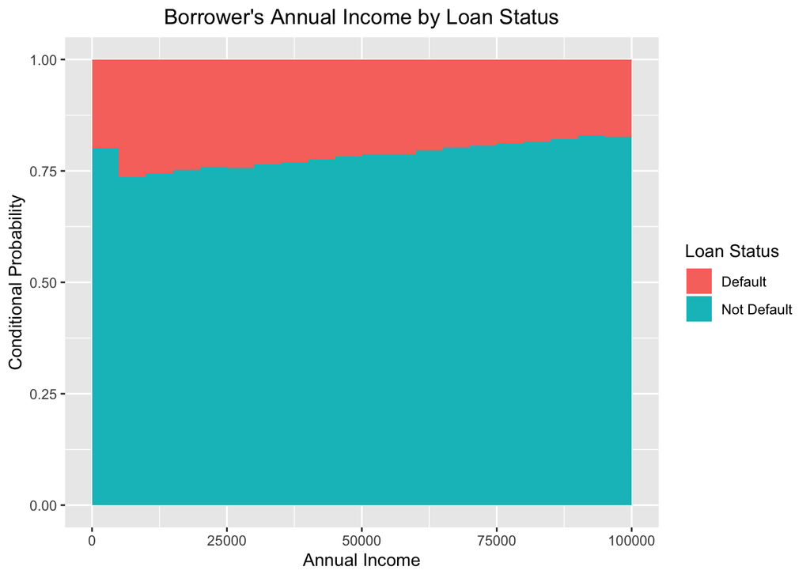

```r
ggplot(data = lending.club.relevant.data, aes(x = annual_inc, fill = loan_status)) +
geom_histogram(breaks = seq(0, 100000, by = 5000), position = "fill", binwidth = 1) + theme(plot.title = element_text(hjust = 0.5)) +

  labs(x = "Annual Income", y =  "Conditional Probability", title = "Borrower's Annual Income by Loan Status", fill = "Loan Status")
```

The stacked column, in overall, tells us that the percentage of defaulters decrease with increase in annual income. In other words, an individual is much more likely to default with lower income than they are with higher annual income. The figure makes intuitive sense.

### 8. Loan Borrower’s Purpose

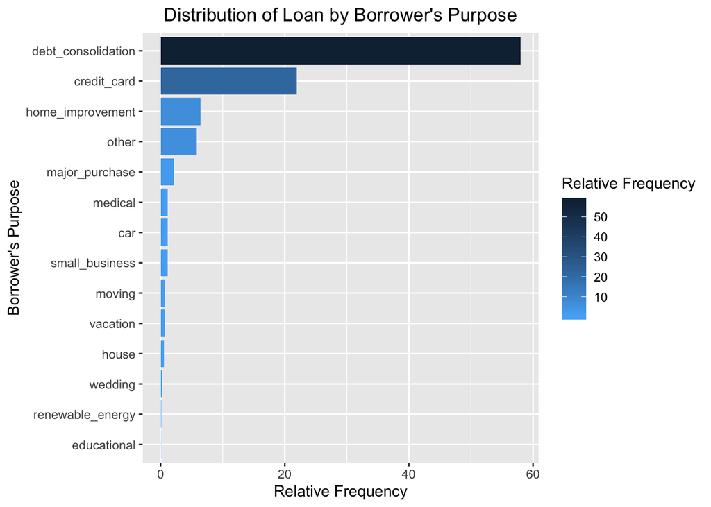

```r
lending.club.relevant.data %>%
  group_by(purpose) %>%
  summarize(frequency = n()) %>%
ggplot(mapping = aes(x = reorder(purpose, frequency), y = frequency * 100 / sum(frequency), fill = frequency * 100 / sum(frequency))) + geom_bar(stat = "identity") +
labs(x = "Borrower's Purpose",  y = "Relative Frequency", title = "Distribution of Loan by Borrower's Purpose", fill = "Relative Frequency") + theme(plot.title = element_text(hjust = 0.5)) +
scale_fill_gradient(low = "#56B1F7", high = "#132B43") + coord_flip()
```

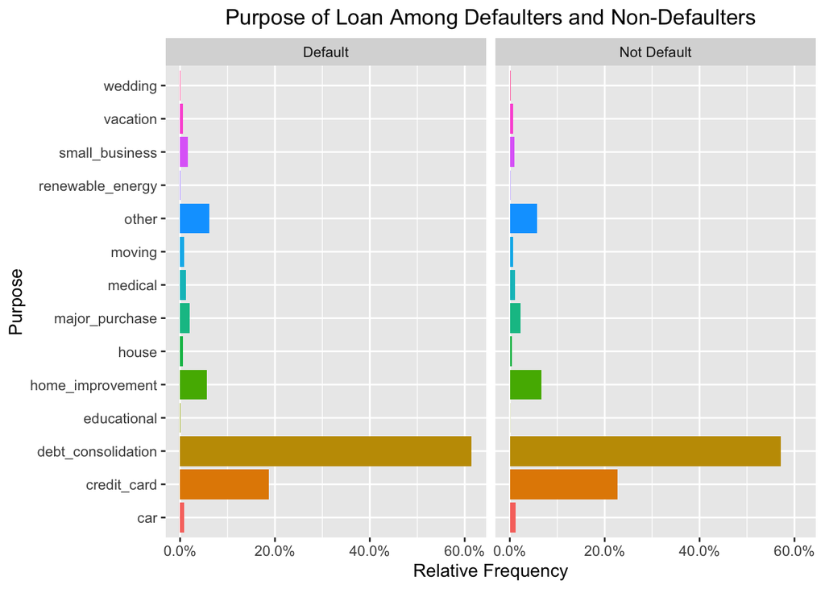

```r
ggplot(lending.club.relevant.data, aes(x = purpose, y = ..prop.., group = loan_status)) +
geom_bar(aes(fill = factor(..x..)), stat="count") +
scale_y_continuous(labels=scales::percent) +
labs (x = "Purpose", y = "Relative Frequency", title = "Purpose of Loan Among Defaulters and Non-Defaulters") +
facet_grid(~loan_status)+
coord_flip() + theme(legend.position = "none", plot.title = element_text(hjust = 0.5))
```

The first bar graph shows us that close to 60% of individuals borrow money to refinance their debt and a little over 20% borrow to pay their credit card bills. And to further refine, the pattern is true across both defaulters and non-defaulters. In other words, borrowers who default not necessarily borrow for any different reason that do non-defaulters.

### 9. Correlation Matrix

Finally, we leveraged correlation as a similarity metric to unearth the patterns among the continuous input variables. As the correlation matrix depicts, we do not observe a subsntial correlation among any two variables. The only high correlation we observe is with `loan_amnt`, `installment`, and `total_pymnt`, which make intuitive sense. Higher the loan amount, higher the installment for a given term. As a result, a borrower’s total payment will also be high.

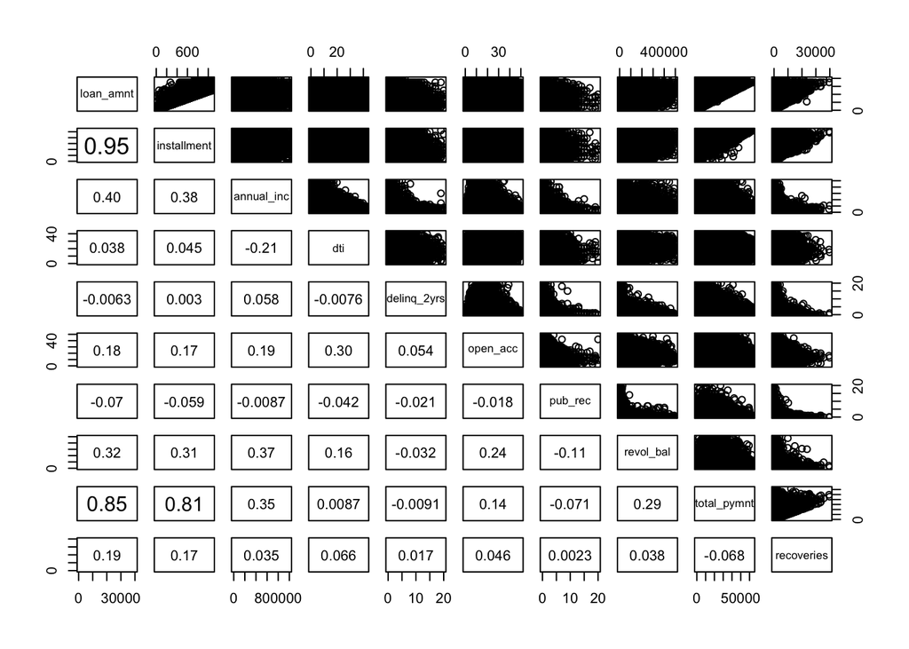

```r
# Getting the correlation matrix
var.names = c('loan_amnt', 'installment','annual_inc','dti','delinq_2yrs',
             'open_acc', 'pub_rec','revol_bal','total_pymnt','recoveries')

panel.cor <- function(x, y, digits = 2, prefix = "", cex.cor, ...)
{
    usr <- par("usr"); on.exit(par(usr))
    par(usr = c(0, 1, 0, 1))
    r <- (cor(x, y))
    txt <- format(c(r, 0.123456789), digits = digits)[1]
    txt <- paste0(prefix, txt)
    if(missing(cex.cor)) cex.cor <- 0.8/strwidth(txt)
    text(0.5, 0.5, txt, cex = pmax(1, cex.cor * r))
}

# Use panel.cor to display correlations in lower panel
test = pairs(lending.club.relevant.data[,var.names], lower.panel = panel.cor)
```

## Methodology

EDA helped us paint a picture of the descriptive features and how their relationship plays out with our outcome variable. As a result, we have used the following 15 variables for our modeling.

We will use supervised learning technique that maps an input to an output based on an exampled input-output pairs. It inferes a function from labeled training data consisting of set of training examples.

Before we building the model, we will split our data into training and test set. First, we are going to train the classifier on the training data. Second, we are going to test performance of our classifier on the test class where labels are unknown. Finally, we will compute several important performance metrics (accuarcy, specificty, sensitiviy, and recall) to gauge the performance of our model. We will end our methodology with a ROC curve to determine and visualize the performance of our model.

**Cut Off:** The best solution for investors would be to choose the cut-off value depending upon which investment strategy they want to play. Deciding which cut-off to choose is very important because based on that value it will be determined whether high sensitivity is required for risky investors(they are fine with True Default being labelled as Not Default) or high specificity is required for conservative investors(they are fine with Not Default being labelled as Default).

**Evaluation:** The two most important measures to evaluate models are accuracy and misclassification rate. But with an imbalanced, accuracy can give misleading conclusion on the model’s performance. We consider other metrics - specificity and sensitivity - as performance measures to later determine threshold and best model.

*Specificity (True Negative Rate)* = # of observations correclty classified as non-events / # observations that did not have the event = TN / (TN + FP)

*Sensitivity (Recall)* = # of observations correclty classified as events/ # of observations that have the event = TP/ (TP+ FN)

As Not-Default is considered as the positive label in our model, specificity is desirable when FP are costly than FN. On the flip side, sensitivity is desirable when FN are more costly than FP.

### Selected Models

We have decided to work with 3 models of different levels of complexity and each having different characteristics. We are going to compare performance as mentioned above. Following are the reasons for our selection of these models:

*1. Logistic Regression*: This is the simplest model and as this is a high dimensional dataset, it has a higher tendency to overfit. Therefore, by using a simple model, we are tackling the issue of overfitting. Also, Logistic regression is easier to implement, interpret, and very efficient to train.

*2. Linear Discriminant Analysis*: Logistic regression also has some disadvantages. It can become unstable when there are few observations from which to estimate the parameters. Also, it can be unstable when the classes are well separated. LDA tackles these issues. Also, LDA can capture interaction effects and provide more complex models than those provided by logistic regression.

We didn’t use QDA because the data has very high dimensions. Therefore, using QDA would have been highly inefficient as it uses separate covariance matrix for each class.

*3. Random Forests*: Random forests can capture complex interactions and also are very flexible. They take advantage of “Wisdom of the crowds” and work well in many situations. They provide a reliable feature importance estimate. Also, they offer efficient estimates of the test error without incurring the cost of repeated model training associated with cross-validation.

Finally, we didn’t use Naive Bayes as it makes a very strong assumption that the predictors are independent. The correlation matrix above shows that such an assumption might not hold. Therefore, we decided to discard this model.

```r
# Removing total_funded as it is always the same as required amount
# Removed correlated terms and also other terms to avoid data leakage
lending.club.relevant.data.subset = subset(lending.club.relevant.data, select = c(1,4:11,12,13,14,17:19))

# 15 variables used in model building
names(lending.club.relevant.data.subset)
```

```
##  [1] "loan_amnt"           "int_rate"            "installment"
##  [4] "grade"               "emp_length"          "home_ownership"
##  [7] "annual_inc"          "verification_status" "issue_d"
## [10] "loan_status"         "purpose"             "dti"
## [13] "open_acc"            "pub_rec"             "revol_bal"
```

```r
# Splitting into training and testing sets
testing.index = sample(1:nrow(lending.club.relevant.data), nrow(lending.club.relevant.data)*0.3)

testing.data = lending.club.relevant.data.subset[testing.index,]

training.data = lending.club.relevant.data.subset[-testing.index,]

# Data frame to store the model AUC details
model_auc_performance = data.frame(model = character(0), auc = numeric(0), stringsAsFactors = FALSE)
```

### Model 1: Logistic Regression

For binary classification where borrower will default or not, we used logistic regression as our first model type. We have used glm funtion to make a classifier and provided the training set to learn the classifier. Then we used predict function on test set to get prediction.

We used confusion matrix and different threshold to identify different configurations of the model different types of investors will utilize.

```r
# LOGISTIC REGRESSION
loan.model.logistic = glm(loan_status~., data = training.data, family = binomial)

# venstor storing the prediction
training.result.logistic = predict(loan.model.logistic, newdata = testing.data, type = "response")

sum(testing.data$loan_status == "Default")
```

```
## [1] 75214
```

```r
# We have labelled not default as positive label and default as negatice label

#cut-off 0.5 threshold
predicted.classes = ifelse(training.result.logistic < 0.5, "Default", "Not Default")


predicted.classes = as.factor(predicted.classes)

# printing confusion matrix
conf.mat = table(testing.data$loan_status, predicted.classes)


# Calculate all metrics
  acc <- sum(diag(conf.mat)) /  nrow(testing.data)
  sens <-conf.mat[2,2] / sum(conf.mat[2,])
  spec <-conf.mat[1,1] / sum(conf.mat[1,])
  ppv <-conf.mat[2,2] / sum(conf.mat[,2])
  npv <-conf.mat[1,1] / sum(conf.mat[,1])
  prec <- ppv
  rec <- sens

  metric.names <- c("accuracy", "sensitivity", "specificity",
                    "ppv", "npv", "precision", "recall")

  metric.vals <- c(acc, sens, spec, ppv, npv, prec, rec)

  # Form into data frame
  full.df <- data.frame(value = metric.vals)

  rownames(full.df) <- metric.names

  output_0.5 = list(conf.mat =conf.mat, perf = full.df)


print(output_0.5)
```

```
## $conf.mat
##              predicted.classes
##               Default Not Default
##   Default        3884       71330
##   Not Default    3139      298857
##
## $perf
##                  value
## accuracy    0.80257947
## sensitivity 0.98960582
## specificity 0.05163932
## ppv         0.80731360
## npv         0.55304001
## precision   0.80731360
## recall      0.98960582
```

```r
#cut-off 0.8 threshold
predicted.classes = ifelse(training.result.logistic < 0.8, "Default", "Not Default")


predicted.classes = as.factor(predicted.classes)

#predicted.classes = factor(predicted.classes, levels = c("Not Default", "Default"))

# printing confusion matrix
conf.mat = table(testing.data$loan_status, predicted.classes)


# Calculate all metrics
  acc <- sum(diag(conf.mat)) /  nrow(testing.data)
  sens <-conf.mat[2,2] / sum(conf.mat[2,])
  spec <-conf.mat[1,1] / sum(conf.mat[1,])
  ppv <-conf.mat[2,2] / sum(conf.mat[,2])
  npv <-conf.mat[1,1] / sum(conf.mat[,1])
  prec <- ppv
  rec <- sens

  metric.names <- c("accuracy", "sensitivity", "specificity",
                    "ppv", "npv", "precision", "recall")

  metric.vals <- c(acc, sens, spec, ppv, npv, prec, rec)

  # Form into data frame
  full.df <- data.frame(value = metric.vals)

  rownames(full.df) <- metric.names

  output_0.8 = list(conf.mat =conf.mat, perf = full.df)


print(output_0.8)
```

```
## $conf.mat
##              predicted.classes
##               Default Not Default
##   Default       50442       24772
##   Not Default  111560      190436
##
## $perf
##                 value
## accuracy    0.6385780
## sensitivity 0.6305911
## specificity 0.6706464
## ppv         0.8848928
## npv         0.3113665
## precision   0.8848928
## recall      0.6305911
```

```r
Roc.Auc.logistic = roc(testing.data$loan_status, training.result.logistic)
model_auc_performance[1,] = c("Logistic Regression", round(Roc.Auc.logistic$auc, 3))
```

### Model 2: Linear Discriminant Analysis

```r
# Linear Discriminant Analysis

lending.model.lda <- lda(loan_status ~ ., data=training.data)

lda.pred <- predict(lending.model.lda, newdata = testing.data, type = "response")

Roc.Auc.lda = roc(testing.data$loan_status, lda.pred$posterior[,"Default"] )
model_auc_performance[2,] = c("Linear Discriminant Analysis", round(Roc.Auc.lda$auc, 3))
```

### Model 3: Random Forest

```r
# RANDOM FOREST

# ideally we would like to make a grid  of number of trees and # of variables in each split
# for computational reasons, we have selected 10 trees and 3 variables

loan.model.randomForest = randomForest(loan_status ~ ., data = training.data, ntree = 10, mtry = 3, importance = TRUE)

training.result.rf=  predict(loan.model.randomForest, newdata = testing.data, type = "prob")

Roc.Auc.random.forest = roc(testing.data$loan_status, training.result.rf[,"Default"])
model_auc_performance[3,] = c("Random Forest", round(Roc.Auc.random.forest$auc, 3))
```

```r
# Compare performance of model on the basis of auc and ROC curve
print(model_auc_performance)
```

```
##                          model   auc
## 1          Logistic Regression 0.707
## 2 Linear Discriminant Analysis 0.706
## 3                Random Forest 0.653
```

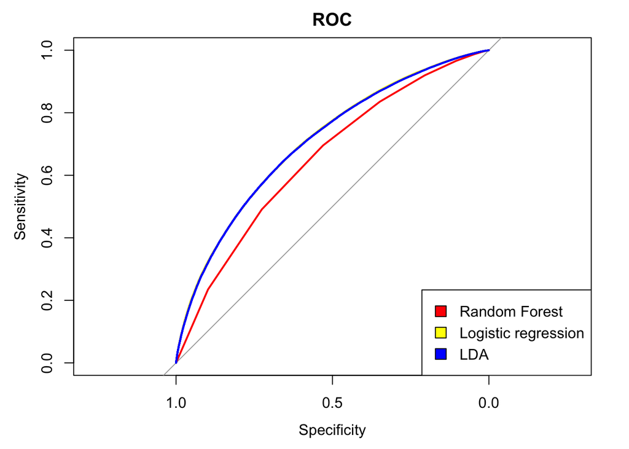

```r
plot(Roc.Auc.random.forest, col = "red",  main = "ROC")
plot(Roc.Auc.logistic, col = "yellow",add = TRUE)
plot(Roc.Auc.lda, col = "blue", lty = 2, add = TRUE)

legend("bottomright",legend=c("Random Forest","Logistic regression","LDA"),fill=c("red","yellow","blue"))
```

As the figure indicates, ROC graphs are not significantly different. We are surprised to find that based on AUC, logistic regression performs the best. LDA also provides a similar performance, as the curve overlaps with the logistic regression. We recommend Logistic Regression as a model of choice for predicting Default loans for this dataset as LDA model are more complex and less interpretable.

An ensemble model, Random Forest is inherently less interpretable. Training a large number of deep trees can have high computational costs (but can be parallelized) and use a lot of memory. Predictions are slower, which may create challenges for applications.

## Discussion and Conclusion

As mentioned above, the logistic regression performed the best among the three chosen models in our dataset and feature engineering. We had catered the cut-off in logistic regression based on an investor’s risk appetite.

However, as with any analytical work, our model also suffers from limitations and leaves room for future improvements. To begin with, we considered both the loan terms (36 months and 60 months) in our model. Although our violin plot suggested that there are no systematic differences among defaulters and loan terms, the length of loan can have significant consequences in the loan amount, tendency to borrow a loan, and as a result, the default rate. Future works can incorporate two different prediction models based on the loan term.

Similarly, because of the gravity of the associated risk in P2P lending, a predictive model to calculate ROI based on the likelihood of the individuals defaulting the loan could also be desirable. Varibles such as the last payment date could be used as a measure of when the borrower defaulted. An investor will equally be interested in *when* the borrower will default and calculate expected ROI based on such a timeline.